# Data Science with R_Capstone Project

Ankita Gairola

2023-08-22

## Project scenario

Your project is to analyze how weather would affect bike-sharing demand in urban areas. To complete this project, you need to first collect and process related weather and bike-sharing demand data from various sources, perform exploratory data analysis on the data, and build predictive models to predict bike-sharing demand. You will combine your results and connect them to a live dashboard displaying an interactive map and associated visualization of the current weather and the estimated bike demand.

## Tasks:

1. Collecting and understanding data from multiple sources
2. Performing data wrangling and preparation with regular expressions and Tidyverse
3. Performing exploratory data analysis and visualization using Tidyverse and ggplot2
4. Performing modelling the data with linear regressions using Tidymodels
5. Building an interactive dashboard using R Shiny

### Web scrape a Global Bike-Sharing Systems Wiki Page

#### Import Packages

install.packages(“tidyverse”)

install.packages(“rio”)

install.packages(“lubridate”)

install.packages(“ggplot2”)

install.packages(“tidymodels”)

install.packages(“ggthemes”)

install.packages(“ggpubr”)

install.packages(“glmnet”)

install.packages(“rvest”)

install.packages(“fastDummies”)

```r
library(rio)

library(lubridate)
library(tidyverse)
```

```r
library(ggplot2)

library(ggpubr)

library(glmnet)
library(rvest)
library(fastDummies)
library(ggthemes)

library(tidymodels)
Sys.setlocale("LC_TIME", "English_Hong Kong")
```

```
## [1] ""
```

```r
options(repr.plot.width = 16, repr.plot.height = 9)
```

#### Task_1: Extract bike sharing systems HTML table from a Wiki page and convert it into a data frame

```r
url = "https://en.wikipedia.org/wiki/List_of_bicycle-sharing_systems"

data <- read_html(url)

table_nodes <- html_nodes(data, "table")

bike_df <- data %>%
  html_element("table") %>%
  html_table()
print(df)
```

[output not shown]

##### Export to csv file

```r
write.csv(bike_df,"E:/Coursera/Data Science with R_Capstone Project/raw_bike_sharing_system.csv")
```

#### Task_2: The current weather data for a city using OpenWeather API

install.packages(“httr”)

```r
library(httr)
```

##### URL for Current Weather API

```r
current_weather_url <- 'https://api.openweathermap.org/data/2.5/weather'
```

##### List to hold URL parameters for current weather API

```r
my_api_key <- "63cbacfaa61878d2acc06654c13fd311"

current_query <- list(q="Seoul",appid=my_api_key,units="metric")
```

##### HTTP request to the current weather API

```r
response <- GET(current_weather_url, query=current_query)
http_type(response)
```

```
## [1] "application/json"
```

##### Read JASON Http data

```r
json_result <- content(response, as="parsed")
json_result
```

```
## $coord
## $coord$lon
## [1] 126.9778
##
## $coord$lat
## [1] 37.5683
##
##
## $weather
## $weather[[1]]
## $weather[[1]]$id
## [1] 804
##
## $weather[[1]]$main
## [1] "Clouds"
##
## $weather[[1]]$description
## [1] "overcast clouds"
##
## $weather[[1]]$icon
## [1] "04d"
##
##
##
## $base
## [1] "stations"
##
## $main
## $main$temp
## [1] 21.89
##
## $main$feels_like
## [1] 22.67
##
## $main$temp_min
## [1] 21.69
##
## $main$temp_max
## [1] 22.66
##
```

[output cut: 39 more lines]

```
## $sys$sunset
## [1] 1692872080
##
##
## $timezone
## [1] 32400
##
## $id
## [1] 1835848
##
## $name
## [1] "Seoul"
##
## $cod
## [1] 200
```

```r
class(json_result)
```

```
## [1] "list"
```

```r
json_result
```

```
## $coord
## $coord$lon
## [1] 126.9778
##
## $coord$lat
## [1] 37.5683
##
##
## $weather
## $weather[[1]]
## $weather[[1]]$id
## [1] 804
##
## $weather[[1]]$main
## [1] "Clouds"
##
## $weather[[1]]$description
## [1] "overcast clouds"
##
## $weather[[1]]$icon
## [1] "04d"
##
##
##
## $base
## [1] "stations"
##
## $main
## $main$temp
## [1] 21.89
##
## $main$feels_like
## [1] 22.67
##
## $main$temp_min
## [1] 21.69
##
## $main$temp_max
## [1] 22.66
##
```

[output cut: 39 more lines]

```
## $sys$sunset
## [1] 1692872080
##
##
## $timezone
## [1] 32400
##
## $id
## [1] 1835848
##
## $name
## [1] "Seoul"
##
## $cod
## [1] 200
```

##### Create some empty vectors to hold data temporarily

```r
city <-c()
weather <- c()
visibility <- c()
temp <- c()
temp_min <- c()
temp_max <- c()
pressure <- c()
humidity <- c()
wind_speed <- c()
wind_deg <- c()
```

##### Assign the values in the json_result list into different vectors

```r
city <- c(city, json_result$name)
weather <- c(weather, json_result$weather[[1]]$main)
visibility <- c(visibility, json_result$visibility)
temp <- c(temp, json_result$main$temp)
temp_min <- c(temp_min, json_result$main$temp_min)
temp_max <- c(temp_max, json_result$main$temp_max)
pressure <- c(pressure, json_result$main$pressure)
humidity <- c(humidity, json_result$main$humidity)
wind_speed <- c(wind_speed, json_result$wind$speed)
wind_deg <- c(wind_deg, json_result$wind$deg)
```

##### Combine all vectors as columns of a data frame

```r
weather_data_frame <- data.frame(city = city,
                                 weather=weather,
                                 visibility=visibility,
                                 temp=temp,
                                 temp_min=temp_min,
                                 temp_max=temp_max,
                                 pressure=pressure,
                                 humidity=humidity,
                                 wind_speed=wind_speed,
                                 wind_deg=wind_deg)
```

```r
print(weather_data_frame)
```

```
##    city weather visibility  temp temp_min temp_max pressure humidity wind_speed
## 1 Seoul  Clouds       3000 21.89    21.69    22.66     1007       97       2.57
##   wind_deg
## 1       40
```

```r
city <- c()
weather <- c()
visibility <- c()
temp <- c()
temp_min <- c()
temp_max <- c()
pressure <- c()
humidity <- c()
wind_speed <- c()
wind_deg <- c()
```

```r
# Get 5 -day weather forecast for a list of cities
weather_forecast_by_cities <- function(city_names) {
  df <- data.frame()
  for (city_name in city_names) {

    #forecast API URL
    forecast_url <-'https://api.openweathermap.org/data/2.5/weather'

    #create query parameter
    forecast_query <- list(q=city_name,appid=my_api_key, units="metric")

    #make HTTP GET call for the given city
    response <- GET(forecast_url, query=forecast_query)

    json_result <- content(response, as="parsed")
    results <- json_result$list

    #Loop the json result
    for(result in results) {
      city <- c(city, city_name)
    }

    # Add R lists into a data frame
    city <- c(city, json_result$name)
    weather <- c(weather, json_result$weather[[1]]$main)
    visibility <- c(visibility, json_result$visibility)
    temp <- c(temp, json_result$main$temp)
    temp_min <-c(temp_min, json_result$main$temp_min)
    temp_max <- c(temp_max, json_result$main$temp_max)
    pressure <- c(pressure, json_result$main$pressure)
    humidity <- c(humidity, json_result$main$humidity)
    wind_speed <- c(wind_speed, json_result$wind$speed)
    wind_deg <-c(wind_deg, json_result$wind$deg)

    #Combine all vector into data frame
    df <- data.frame(city = city,
                            weather=weather,
                             visibility=visibility,
                             temp=temp,
                             temp_min=temp_min,
                             temp_max=temp_max,
                             pressure=pressure,
                             humidity=humidity,
                             wind_speed=wind_speed,
                             wind_deg=wind_deg)
  }
  return(df)
}
```

```r
cities <- c("Seoul", "Washington, D.C.", "Paris", "Suzhou", "New Delhi", "Kyoto", "Cologne", "London" )
cities_weather_df <- weather_forecast_by_cities(cities)
print(cities_weather_df)
```

```
##         city weather visibility  temp temp_min temp_max pressure humidity
## 1      Seoul  Clouds       3000 21.89    21.69    22.66     1007       97
## 2 Washington  Clouds      10000 23.11    21.85    23.99     1013       35
## 3      Paris  Clouds      10000 25.52    21.81    26.91     1016       68
## 4     Suzhou   Clear      10000 23.29    23.29    23.29     1007       89
## 5  New Delhi    Mist       3500 27.09    27.09    27.09     1000       89
## 6      Kyoto    Rain      10000 26.67    24.98    27.59     1010       87
## 7    Cologne   Clear      10000 19.55    17.64    21.64     1020       72
## 8     London  Clouds      10000 20.93    18.36    22.27     1015       71
##   wind_speed wind_deg
## 1       2.57       40
## 2       1.15      250
## 3       3.09       60
## 4       1.48       33
## 5       1.54      250
## 6       2.55      102
## 7       0.51        0
## 8       2.06      190
```

#### Task_4: Download datasets as csv files from cloud storage

##### some general city information such as name and locations

```r
url <- "https://cf-courses-data.s3.us.cloud-object-storage.appdomain.cloud/IBMDeveloperSkillsNetwork-RP0321EN-SkillsNetwork/labs/datasets/raw_worldcities.csv"


download.file(url, destfile = "raw_worldcities.csv")
```

##### specific hourly Seoul bike sharing demand dataset

```r
url <- "https://cf-courses-data.s3.us.cloud-object-storage.appdomain.cloud/IBMDeveloperSkillsNetwork-RP0321EN-SkillsNetwork/labs/datasets/raw_seoul_bike_sharing.csv"


download.file(url, destfile = "raw_seoul_bike_sharing.csv")
```

##### Download raw_cities_weather_forecast

```r
url <- "https://cf-courses-data.s3.us.cloud-object-storage.appdomain.cloud/IBMDeveloperSkillsNetwork-RP0321EN-SkillsNetwork/labs/datasets/raw_cities_weather_forecast.csv"

download.file(url, destfile = "raw_cities_weather_forecast.csv")
```

### Data Wrangling with Regular Expressions

```r
dataset_list <- c('raw_bike_sharing_systems.csv', 'raw_seoul_bike_sharing.csv', 'raw_cities_weather_forecast.csv', 'raw_worldcities.csv')
```

#### Task_5: Standardize column names for all collected datasets

##### Convert iterate over the above datasets and convert their column names

```r
for (dataset_name in dataset_list) {
  if (file.exists(dataset_name)) {  # Check if the file exists
    dataset <- read.csv(dataset_name, fileEncoding = "UTF-8")  # Specify encoding if needed
    names(dataset) <- toupper(names(dataset))
    names(dataset) <- str_replace_all(names(dataset), " ", "_")
    write.csv(dataset, dataset_name, row.names = FALSE)
  } else {
    cat("File not found:", dataset_name, "\n")
  }
}
```

```
## File not found: raw_bike_sharing_systems.csv
```

### Process the web-scraped bike sharing system dataset

##### Load Dataset

```r
bike_sharing_df <- read.csv("E:/Coursera/Data Science with R_Capstone Project/raw_bike_sharing_system.csv")

head(bike_sharing_df)
```

```
##   X   Country                  City                 Name            System
## 1 1   Albania             Tirana[5]             Ecovolis
## 2 2 Argentina    Buenos Aires[6][7]              Ecobici Serttel Brasil[8]
## 3 3 Argentina           Mendoza[10]            Metrobici
## 4 4 Argentina               Rosario  Mi Bici Tu Bici[11]
## 5 5 Argentina San Lorenzo, Santa Fe             Biciudad          Biciudad
## 6 6 Australia         Melbourne[12] Melbourne Bike Share         PBSC & 8D
##                       Operator         Launched         Discontinued Stations
## 1                                    March 2011                             8
## 2 Bike In Baires Consortium[9]             2010                           400
## 3                                          2014                             2
## 4                               2 December 2015                            47
## 5                              27 November 2016                             8
## 6                     Motivate        June 2010 30 November 2019[13]       53
##   Bicycles Daily.ridership
## 1      200
## 2     4000           21917
## 3       40
## 4      480
## 5       80
## 6      676
```

```r
sub_bike_sharing_df <- bike_sharing_df %>%
  select(Country, City, System, Bicycles)


sub_bike_sharing_df %>%
  summarize_all(class) %>%
  gather(variable, class)
```

```
##   variable     class
## 1  Country character
## 2     City character
## 3   System character
## 4 Bicycles character
```

```r
find_character <- function(strings) grepl("[^0-9]", strings)

sub_bike_sharing_df %>%
  select(Bicycles) %>% #Use the function to check BICYCLES column
  filter(find_character(Bicycles)) %>%
  slice(0:10)
```

```
##                               Bicycles
## 1                      1790 (2019)[21]
## 2                          4200 (2021)
## 3                             4115[25]
## 4  7270 (regular)  2395 (electric)[38]
## 5                              310[65]
## 6                              500[75]
## 7                                 [78]
## 8                              180[79]
## 9                              600[82]
## 10          initially 800 (later 2500)
```

Because there are some values associated with numeric and non-numeric value, BYCICLES was classified as character.

Check if COUNTRY, CITY, SYSTEM have any reference link, such as Melbourne[12]

##### Create a function to check if there is any reference link in the values

```r
ref_pattern <- "\\[[A-z0-9]+\\]"
find_reference_pattern <- function(strings) grepl(ref_pattern, strings)
```

##### Check whether the CITY column has any reference links

```r
sub_bike_sharing_df %>%
  select(City) %>%
  filter(find_reference_pattern(City)) %>%
  slice(1:10)
```

```
##                       City
## 1                Tirana[5]
## 2       Buenos Aires[6][7]
## 3              Mendoza[10]
## 4            Melbourne[12]
## 5            Melbourne[12]
## 6         Brisbane[14][15]
## 7        Lower Austria[16]
## 8  Different locations[19]
## 9             Brussels[24]
## 10               Namur[26]
```

##### Check whether the System column has any reference links

```r
sub_bike_sharing_df %>%
    select(System) %>%
    filter(find_reference_pattern(System)) %>%
    slice(0:10)
```

```
##                              System
## 1                 Serttel Brasil[8]
## 2                      EasyBike[64]
## 3                        4 Gen.[72]
## 4             3 Gen. SmooveKey[135]
## 5 3 Gen. Smoove[162][163][164][160]
## 6                3 Gen. Smoove[200]
## 7                3 Gen. Smoove[202]
## 8                3 Gen. Smoove[204]
```

#### Task_6: Remove undesired reference links using regular expressions

##### remove reference link

```r
remove_ref <- function(strings) {
  ref_pattern <- "\\[[A-z0-9]+\\]" # Define a pattern matching a reference link such as [1]
  result <- stringr::str_replace_all(strings,ref_pattern,"")  # Replace all matched substrings with a white space
  result <-  trimws(result)
    return(result)
}
```

install.packages(“magrittr”)

install.packages(“dplyr”)

```r
library(magrittr)
library(dplyr)
```

##### Use the function to remove the reference links

```r
sub_bike_sharing_df %<>% #use mutate and remove_ref fcn to remove ref in CITY and SYSTEM
  mutate(System=remove_ref(System),
         City=remove_ref(City))
```

##### Check whether all reference links are removed

```r
sub_bike_sharing_df %>%
  select(Country, City, System, Bicycles) %>%
  filter (find_reference_pattern(Country) | find_reference_pattern(City) | find_reference_pattern(City) |find_reference_pattern(Bicycles) )
```

```
##           Country                                            City
## 1         Belgium                             Different locations
## 2         Belgium                                        Brussels
## 3          Canada                                        Montreal
## 4          Cyprus                      Limassol, Nicosia District
## 5         Czechia                                          Prague
## 6         Czechia                                        Prague 7
## 7         Czechia                                       Prostějov
## 8         Czechia                                         Ostrava
## 9         Denmark                                           Farsø
## 10        Finland                                         Kouvola
## 11        Finland                                          Kuopio
## 12        Finland                                           Lahti
## 13        Finland                                    Lappeenranta
## 14        Finland                                            Pori
```

[output cut: 67 more lines]

#### Task_7: Extract the numeric value using regular expressions

```r
extract_num <- function(columns) {
  digitals_pattern <- "\\d+" #define a pattern matching digital substring
  str_extract(columns,digitals_pattern) %>%
  as.numeric()
}
```

install.packages(“stringr”)

```r
library(stringr)
```

```r
sub_bike_sharing_df %<>% #use mutate and to apply function to BICYLCLES
  mutate(Bicycles=extract_num(Bicycles))
```

```r
write.csv(sub_bike_sharing_df, "E:/Coursera/Data Science with R_Capstone Project/bike_sharing_system.csv")
```

### Data Wrangling with dplyr

Quick look at the dataset

```r
summary(bike_sharing_df)
```

```
##        X           Country              City               Name
##  Min.   :  1.0   Length:556         Length:556         Length:556
##  1st Qu.:139.8   Class :character   Class :character   Class :character
##  Median :278.5   Mode  :character   Mode  :character   Mode  :character
##  Mean   :278.5
##  3rd Qu.:417.2
##  Max.   :556.0
##     System            Operator           Launched         Discontinued
##  Length:556         Length:556         Length:556         Length:556
##  Class :character   Class :character   Class :character   Class :character
##  Mode  :character   Mode  :character   Mode  :character   Mode  :character
##
##
##
##    Stations           Bicycles         Daily.ridership
##  Length:556         Length:556         Length:556
##  Class :character   Class :character   Class :character
##  Mode  :character   Mode  :character   Mode  :character
##
##
##
```

```r
dim(bike_sharing_df)
```

```
## [1] 556  11
```

#### Task_8: Detect and handle missing values

```r
dataset_list <- c('bike_sharing_system.csv','raw_seoul_bike_sharing.csv')
for (dataset_name in dataset_list) {
  dataset <- read.csv(dataset_name)
  names(dataset) <- toupper(names(dataset))
  names(dataset) <- str_replace_all(names(dataset), " ", "_")
  write.csv(dataset, dataset_name, row.names = FALSE)
}
```

```r
bike_sharing_df <- read.csv("raw_seoul_bike_sharing.csv")
summary(bike_sharing_df)
```

```
##      DATE           RENTED_BIKE_COUNT      HOUR        TEMPERATURE
##  Length:8760        Min.   :   2.0    Min.   : 0.00   Min.   :-17.80
##  Class :character   1st Qu.: 214.0    1st Qu.: 5.75   1st Qu.:  3.40
##  Mode  :character   Median : 542.0    Median :11.50   Median : 13.70
##                     Mean   : 729.2    Mean   :11.50   Mean   : 12.87
##                     3rd Qu.:1084.0    3rd Qu.:17.25   3rd Qu.: 22.50
##                     Max.   :3556.0    Max.   :23.00   Max.   : 39.40
##                     NA's   :295                       NA's   :11
##     HUMIDITY       WIND_SPEED      VISIBILITY   DEW_POINT_TEMPERATURE
##  Min.   : 0.00   Min.   :0.000   Min.   :  27   Min.   :-30.600
##  1st Qu.:42.00   1st Qu.:0.900   1st Qu.: 940   1st Qu.: -4.700
##  Median :57.00   Median :1.500   Median :1698   Median :  5.100
##  Mean   :58.23   Mean   :1.725   Mean   :1437   Mean   :  4.074
##  3rd Qu.:74.00   3rd Qu.:2.300   3rd Qu.:2000   3rd Qu.: 14.800
##  Max.   :98.00   Max.   :7.400   Max.   :2000   Max.   : 27.200
##
##  SOLAR_RADIATION     RAINFALL          SNOWFALL         SEASONS
##  Min.   :0.0000   Min.   : 0.0000   Min.   :0.00000   Length:8760
##  1st Qu.:0.0000   1st Qu.: 0.0000   1st Qu.:0.00000   Class :character
##  Median :0.0100   Median : 0.0000   Median :0.00000   Mode  :character
##  Mean   :0.5691   Mean   : 0.1487   Mean   :0.07507
##  3rd Qu.:0.9300   3rd Qu.: 0.0000   3rd Qu.:0.00000
##  Max.   :3.5200   Max.   :35.0000   Max.   :8.80000
##
##    HOLIDAY          FUNCTIONING_DAY
##  Length:8760        Length:8760
##  Class :character   Class :character
##  Mode  :character   Mode  :character
##
##
##
##
```

```r
dim(bike_sharing_df)
```

```
## [1] 8760   14
```

##### missing values in the TEMPERATURE column

```r
bike_sharing_df %>%
                filter(is.na(TEMPERATURE))
```

```
##          DATE RENTED_BIKE_COUNT HOUR TEMPERATURE HUMIDITY WIND_SPEED VISIBILITY
## 1  07/06/2018              3221   18          NA       57        2.7       1217
## 2  12/06/2018              1246   14          NA       45        2.2       1961
## 3  13/06/2018              2664   17          NA       57        3.3        919
## 4  17/06/2018              2330   17          NA       58        3.3        865
## 5  20/06/2018              2741   19          NA       61        2.7       1236
## 6  30/06/2018              1144   13          NA       87        1.7        390
## 7  05/07/2018               827   10          NA       75        1.1       1028
## 8  11/07/2018               634    9          NA       96        0.6        450
## 9  12/07/2018               593    6          NA       93        1.1        852
## 10 21/07/2018               347    4          NA       77        1.2       1203
## 11 21/08/2018              1277   23          NA       75        0.1       1892
##    DEW_POINT_TEMPERATURE SOLAR_RADIATION RAINFALL SNOWFALL SEASONS    HOLIDAY
## 1                   16.4            0.96      0.0        0  Summer No Holiday
## 2                   12.7            1.39      0.0        0  Summer No Holiday
```

[output cut: 21 more lines]

##### missing value in RENTED_BIKE_COUNT column

```r
bike_sharing_df %>%
                filter(is.na(RENTED_BIKE_COUNT))
```

```
##           DATE RENTED_BIKE_COUNT HOUR TEMPERATURE HUMIDITY WIND_SPEED
## 1   11/04/2018                NA    0       14.40       82        4.6
## 2   11/04/2018                NA    1       13.60       81        3.6
## 3   11/04/2018                NA    2       12.70       80        3.9
## 4   11/04/2018                NA    3       11.60       81        3.1
## 5   11/04/2018                NA    4       10.20       83        3.5
## 6   11/04/2018                NA    5        9.70       84        1.7
## 7   11/04/2018                NA    6        9.00       86        2.0
## 8   11/04/2018                NA    7        8.80       85        1.1
## 9   11/04/2018                NA    8        9.70       77        1.6
## 10  11/04/2018                NA    9       11.80       59        2.1
## 11  11/04/2018                NA   10       13.30       51        4.1
## 12  11/04/2018                NA   11       14.90       44        4.0
## 13  11/04/2018                NA   12       15.70       46        3.9
## 14  11/04/2018                NA   13       15.60       38        4.7
```

[output cut: 873 more lines]

##### calculate the average temperature in summer

```r
summer_temp <- bike_sharing_df[bike_sharing_df$SEASONS == "Summer", ]
summer_avg_temp <- mean(summer_temp$TEMPERATURE, na.rm=TRUE)
print(summer_avg_temp)
```

```
## [1] 26.58771
```

##### Impute missing values for TEMPERATURE column with summer average temperature

```r
bike_sharing_df["TEMPERATURE"][is.na(bike_sharing_df["TEMPERATURE"])] <- summer_avg_temp
```

##### summary of the dataset

```r
summary(bike_sharing_df)
```

```
##      DATE           RENTED_BIKE_COUNT      HOUR        TEMPERATURE
##  Length:8760        Min.   :   2.0    Min.   : 0.00   Min.   :-17.80
##  Class :character   1st Qu.: 214.0    1st Qu.: 5.75   1st Qu.:  3.50
##  Mode  :character   Median : 542.0    Median :11.50   Median : 13.70
##                     Mean   : 729.2    Mean   :11.50   Mean   : 12.88
##                     3rd Qu.:1084.0    3rd Qu.:17.25   3rd Qu.: 22.50
##                     Max.   :3556.0    Max.   :23.00   Max.   : 39.40
##                     NA's   :295
##     HUMIDITY       WIND_SPEED      VISIBILITY   DEW_POINT_TEMPERATURE
##  Min.   : 0.00   Min.   :0.000   Min.   :  27   Min.   :-30.600
##  1st Qu.:42.00   1st Qu.:0.900   1st Qu.: 940   1st Qu.: -4.700
##  Median :57.00   Median :1.500   Median :1698   Median :  5.100
##  Mean   :58.23   Mean   :1.725   Mean   :1437   Mean   :  4.074
##  3rd Qu.:74.00   3rd Qu.:2.300   3rd Qu.:2000   3rd Qu.: 14.800
##  Max.   :98.00   Max.   :7.400   Max.   :2000   Max.   : 27.200
##
##  SOLAR_RADIATION     RAINFALL          SNOWFALL         SEASONS
##  Min.   :0.0000   Min.   : 0.0000   Min.   :0.00000   Length:8760
##  1st Qu.:0.0000   1st Qu.: 0.0000   1st Qu.:0.00000   Class :character
##  Median :0.0100   Median : 0.0000   Median :0.00000   Mode  :character
##  Mean   :0.5691   Mean   : 0.1487   Mean   :0.07507
##  3rd Qu.:0.9300   3rd Qu.: 0.0000   3rd Qu.:0.00000
##  Max.   :3.5200   Max.   :35.0000   Max.   :8.80000
##
##    HOLIDAY          FUNCTIONING_DAY
##  Length:8760        Length:8760
##  Class :character   Class :character
##  Mode  :character   Mode  :character
##
##
##
##
```

##### Save the dataset as `seoul_bike_sharing.csv

```r
write.csv(bike_sharing_df, "E:/Coursera/Data Science with R_Capstone Project/seoul_bike_sharing.csv")
```

#### Task_9: Create indicator (dummy) variables for categorical variables

```r
bike_sharing_df <- read.csv("E:/Coursera/Data Science with R_Capstone Project/seoul_bike_sharing.csv")
```

##### Using mutate() function to convert HOUR column into character type

```r
bike_sharing_df %>%
  mutate(HOUR=as.character(HOUR)) %>%  #convert HOUR to character because it's from 0 to 23
head(10)
```

```
##     X       DATE RENTED_BIKE_COUNT HOUR TEMPERATURE HUMIDITY WIND_SPEED
## 1   1 01/12/2017               254    0        -5.2       37        2.2
## 2   2 01/12/2017               204    1        -5.5       38        0.8
## 3   3 01/12/2017               173    2        -6.0       39        1.0
## 4   4 01/12/2017               107    3        -6.2       40        0.9
## 5   5 01/12/2017                78    4        -6.0       36        2.3
## 6   6 01/12/2017               100    5        -6.4       37        1.5
## 7   7 01/12/2017               181    6        -6.6       35        1.3
## 8   8 01/12/2017               460    7        -7.4       38        0.9
## 9   9 01/12/2017               930    8        -7.6       37        1.1
## 10 10 01/12/2017               490    9        -6.5       27        0.5
##    VISIBILITY DEW_POINT_TEMPERATURE SOLAR_RADIATION RAINFALL SNOWFALL SEASONS
## 1        2000                 -17.6            0.00        0        0  Winter
## 2        2000                 -17.6            0.00        0        0  Winter
## 3        2000                 -17.7            0.00        0        0  Winter
```

[output cut: 18 more lines]

install.packages(“pacman”)

```r
library(pacman)
```

```r
pacman:: p_load(fastDummies)
```

##### Convert SEASONS, HOLIDAY, FUNCTIONING_DAY, and HOUR columns into indicator columns.

```r
bike_sharing_df <- dummy_cols(bike_sharing_df, select_columns = "HOUR")
bike_sharing_df <- dummy_cols(bike_sharing_df, select_columns = "HOLIDAY")
bike_sharing_df <- dummy_cols(bike_sharing_df, select_columns = "SEASONS")

#Change the colnames for shorterning
colnames(bike_sharing_df)[c(40,41,42,43,44,45)] <- c("HOLIDAY", "NO HOLIDAY", "AUTUMN", "SPRING", "SUMMER","WINTER")
```

##### Save the dataset as `seoul_bike_sharing_converted.csv`

```r
write.csv(bike_sharing_df, "E:/Coursera/Data Science with R_Capstone Project/seoul_bike_sharing_converted.csv")
```

#### Task_10: Normalize data using Min-Max normalization

```r
minmax_norm <- function(x){
  (x-min(x))/(max(x)-min(x))}
```

```r
bike_sharing_df <- read.csv("E:/Coursera/Data Science with R_Capstone Project/seoul_bike_sharing_converted.csv")

#Apply min-max normalization function to numerical columns in df

bike_sharing_df %<>%
  mutate(TEMPERATURE = minmax_norm(TEMPERATURE),
         HUMIDITY = minmax_norm(HUMIDITY),
         WIND_SPEED = minmax_norm(WIND_SPEED),
         VISIBILITY = minmax_norm(VISIBILITY),
         DEW_POINT_TEMPERATURE = minmax_norm(DEW_POINT_TEMPERATURE),
         SOLAR_RADIATION = minmax_norm(SOLAR_RADIATION),
         RAINFALL = minmax_norm(RAINFALL),
         SNOWFALL = minmax_norm(SNOWFALL))
head(bike_sharing_df)
```

```
##   X.1 X       DATE RENTED_BIKE_COUNT HOUR TEMPERATURE  HUMIDITY WIND_SPEED
## 1   1 1 01/12/2017               254    0   0.2202797 0.3775510  0.2972973
## 2   2 2 01/12/2017               204    1   0.2150350 0.3877551  0.1081081
## 3   3 3 01/12/2017               173    2   0.2062937 0.3979592  0.1351351
## 4   4 4 01/12/2017               107    3   0.2027972 0.4081633  0.1216216
## 5   5 5 01/12/2017                78    4   0.2062937 0.3673469  0.3108108
## 6   6 6 01/12/2017               100    5   0.1993007 0.3775510  0.2027027
##   VISIBILITY DEW_POINT_TEMPERATURE SOLAR_RADIATION RAINFALL SNOWFALL SEASONS
## 1          1             0.2249135               0        0        0  Winter
## 2          1             0.2249135               0        0        0  Winter
## 3          1             0.2231834               0        0        0  Winter
## 4          1             0.2249135               0        0        0  Winter
## 5          1             0.2076125               0        0        0  Winter
## 6          1             0.2058824               0        0        0  Winter
##      HOLIDAY FUNCTIONING_DAY HOUR_0 HOUR_1 HOUR_2 HOUR_3 HOUR_4 HOUR_5 HOUR_6
```

[output cut: 27 more lines]

##### Save the dataset as `seoul_bike_sharing_converted_normalized.csv

```r
write.csv(bike_sharing_df,"E:/Coursera/Data Science with R_Capstone Project/seoul_bike_sharing_converted_normalized.csv")
```

### Standardize the column names again for the new datasets

```r
dataset_list <- c('seoul_bike_sharing.csv', 'seoul_bike_sharing_converted.csv', 'seoul_bike_sharing_converted_normalized.csv')

for (dataset_name in dataset_list) {
  dataset <- read.csv(dataset_name)
  names(dataset) <- toupper(names(dataset))
  names(dataset) <- str_replace_all(names(dataset), " ", "_")
  write.csv(dataset, dataset_name, row.names = FALSE)
}
```

### Exploratory Data Analysis with tidyverse and ggplot2

### Task_11: Load the dataset

```r
seoul_bike_sharing <- read.csv("E:/Coursera/Data Science with R_Capstone Project/seoul_bike_sharing.csv")

str(seoul_bike_sharing)
```

```
## 'data.frame':    8760 obs. of  15 variables:
##  $ X                    : int  1 2 3 4 5 6 7 8 9 10 ...
##  $ DATE                 : chr  "01/12/2017" "01/12/2017" "01/12/2017" "01/12/2017" ...
##  $ RENTED_BIKE_COUNT    : int  254 204 173 107 78 100 181 460 930 490 ...
##  $ HOUR                 : int  0 1 2 3 4 5 6 7 8 9 ...
##  $ TEMPERATURE          : num  -5.2 -5.5 -6 -6.2 -6 -6.4 -6.6 -7.4 -7.6 -6.5 ...
##  $ HUMIDITY             : int  37 38 39 40 36 37 35 38 37 27 ...
##  $ WIND_SPEED           : num  2.2 0.8 1 0.9 2.3 1.5 1.3 0.9 1.1 0.5 ...
##  $ VISIBILITY           : int  2000 2000 2000 2000 2000 2000 2000 2000 2000 1928 ...
##  $ DEW_POINT_TEMPERATURE: num  -17.6 -17.6 -17.7 -17.6 -18.6 -18.7 -19.5 -19.3 -19.8 -22.4 ...
##  $ SOLAR_RADIATION      : num  0 0 0 0 0 0 0 0 0.01 0.23 ...
##  $ RAINFALL             : num  0 0 0 0 0 0 0 0 0 0 ...
##  $ SNOWFALL             : num  0 0 0 0 0 0 0 0 0 0 ...
##  $ SEASONS              : chr  "Winter" "Winter" "Winter" "Winter" ...
##  $ HOLIDAY              : chr  "No Holiday" "No Holiday" "No Holiday" "No Holiday" ...
##  $ FUNCTIONING_DAY      : chr  "Yes" "Yes" "Yes" "Yes" ...
```

#### Task_12: Recast DATE as a date

```r
seoul_bike_sharing$DATE = as.Date(seoul_bike_sharing$DATE,format="%d/%m/%Y") #recast date as a date format

seoul_bike_sharing$HOUR <- factor(seoul_bike_sharing$HOUR, levels = 0:23, ordered = TRUE) #cast the HOUR as categorical variables

seoul_bike_sharing$SEASONS <- factor(seoul_bike_sharing$SEASONS, levels=c("Winter", "Spring", "Summer","Autumn"))

class(seoul_bike_sharing$HOUR)
```

```
## [1] "ordered" "factor"
```

#### Task_13 - Cast HOURS as a categorical variable

```r
class(seoul_bike_sharing$DATE)
```

```
## [1] "Date"
```

```r
class(seoul_bike_sharing$SEASONS)
```

```
## [1] "factor"
```

```r
sum(is.na(seoul_bike_sharing))
```

```
## [1] 295
```

### Descriptive Statistics

#### Task_14: Dataset Summary

```r
summary(seoul_bike_sharing)
```

```
##        X             DATE            RENTED_BIKE_COUNT      HOUR
##  Min.   :   1   Min.   :2017-12-01   Min.   :   2.0    0      : 365
##  1st Qu.:2191   1st Qu.:2018-03-02   1st Qu.: 214.0    1      : 365
##  Median :4380   Median :2018-06-01   Median : 542.0    2      : 365
##  Mean   :4380   Mean   :2018-06-01   Mean   : 729.2    3      : 365
##  3rd Qu.:6570   3rd Qu.:2018-08-31   3rd Qu.:1084.0    4      : 365
##  Max.   :8760   Max.   :2018-11-30   Max.   :3556.0    5      : 365
##                                      NA's   :295       (Other):6570
##   TEMPERATURE        HUMIDITY       WIND_SPEED      VISIBILITY
##  Min.   :-17.80   Min.   : 0.00   Min.   :0.000   Min.   :  27
##  1st Qu.:  3.50   1st Qu.:42.00   1st Qu.:0.900   1st Qu.: 940
##  Median : 13.70   Median :57.00   Median :1.500   Median :1698
##  Mean   : 12.88   Mean   :58.23   Mean   :1.725   Mean   :1437
##  3rd Qu.: 22.50   3rd Qu.:74.00   3rd Qu.:2.300   3rd Qu.:2000
##  Max.   : 39.40   Max.   :98.00   Max.   :7.400   Max.   :2000
##
##  DEW_POINT_TEMPERATURE SOLAR_RADIATION     RAINFALL          SNOWFALL
##  Min.   :-30.600       Min.   :0.0000   Min.   : 0.0000   Min.   :0.00000
##  1st Qu.: -4.700       1st Qu.:0.0000   1st Qu.: 0.0000   1st Qu.:0.00000
##  Median :  5.100       Median :0.0100   Median : 0.0000   Median :0.00000
##  Mean   :  4.074       Mean   :0.5691   Mean   : 0.1487   Mean   :0.07507
##  3rd Qu.: 14.800       3rd Qu.:0.9300   3rd Qu.: 0.0000   3rd Qu.:0.00000
##  Max.   : 27.200       Max.   :3.5200   Max.   :35.0000   Max.   :8.80000
##
##    SEASONS       HOLIDAY          FUNCTIONING_DAY
##  Winter:2160   Length:8760        Length:8760
##  Spring:2208   Class :character   Class :character
##  Summer:2208   Mode  :character   Mode  :character
##  Autumn:2184
##
##
##
```

#### Task_15: Based on the above stats, calculate how many Holidays there are.

```r
holiday_count <- table(seoul_bike_sharing$HOLIDAY)
num_holiday <- holiday_count['Holiday']
num_holiday
```

```
## Holiday
##     432
```

#### Task_16: Calculate the percentage of records that fall on a holiday.

```r
num_holiday/(num_holiday +holiday_count['No Holiday'])
```

```
##    Holiday
## 0.04931507
```

#### Task_17: Given there is exactly a full year of data, determine how many records we expect to have.

```r
# Define the frequency of data recording (e.g., daily)
data_frequency <- "daily"

# Define the number of days in a year
days_in_year <- 365

# Calculate the number of records in a year
if (data_frequency == "daily") {
  num_records_in_year <- days_in_year
} else if (data_frequency == "hourly") {
  # If recorded hourly, calculate records per day and multiply by days in a year
  records_per_day <- 24  # 24 records per day if hourly
  num_records_in_year <- records_per_day * days_in_year
} else {
  # Add additional conditions for other data frequencies if needed
  print("Unsupported data frequency")
}

# Print the result
print(paste("Number of records in a year:", num_records_in_year))
```

[output not shown]

#### Task_18: Given the observations for the ‘FUNCTIONING_DAY’ how many records must there be?

```r
# Assuming you have a data frame named 'your_data' with a 'FUNCTIONING_DAY' column
# Count the unique values of 'FUNCTIONING_DAY'
unique_functioning_days <- unique(seoul_bike_sharing$FUNCTIONING_DAY)

# Calculate the number of records based on unique functioning days
num_records <- length(unique_functioning_days)

# Print the result
print(paste("Number of records based on 'FUNCTIONING_DAY':", num_records))
```

```
## [1] "Number of records based on 'FUNCTIONING_DAY': 2"
```

#### Task_19: Calculate the seasonal total rainfall and snowfall.

```r
seasonal_total <- seoul_bike_sharing %>%
  group_by(SEASONS) %>%
  summarize(total_rainfall=sum(RAINFALL), total_snowfall=sum(SNOWFALL))
seasonal_total
```

```
## # A tibble: 4 × 3
##   SEASONS total_rainfall total_snowfall
##   <fct>            <dbl>          <dbl>
## 1 Winter            70.9           535.
## 2 Spring           404.              0
## 3 Summer           560.              0
## 4 Autumn           268.            123
```

### Data Visualization

#### Task_20: Create a scatter plot of RENTED_BIKE_COUNT vs DATE

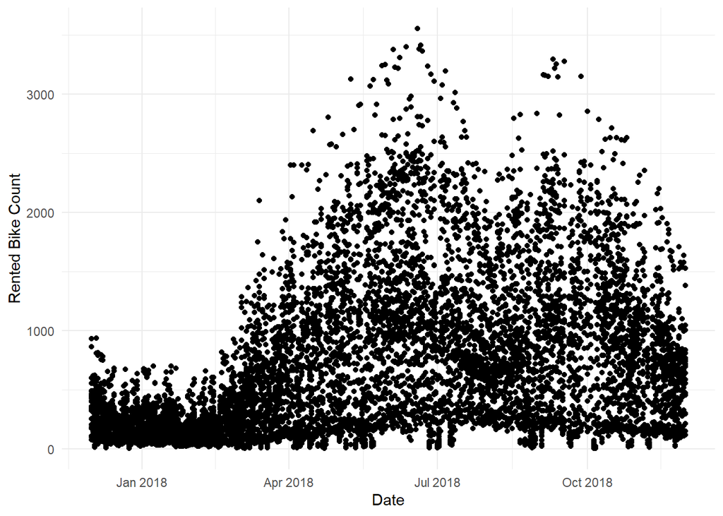

```r
ggplot(seoul_bike_sharing, aes(x = DATE, y = RENTED_BIKE_COUNT)) +
  geom_point() +
  labs(x = "Date", y = "Rented Bike Count") +
  theme_minimal()
```

#### Task_21: Create the same plot of the RENTED_BIKE_COUNT time series, but now add HOURS as the colour.

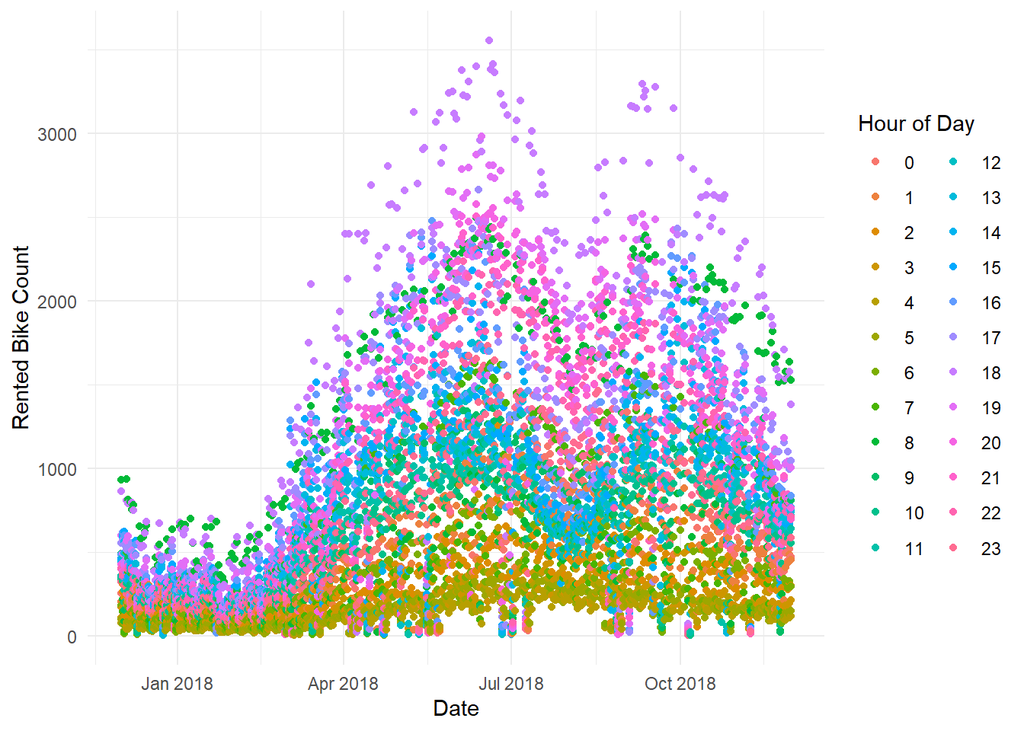

```r
seoul_bike_sharing %>%
  ggplot(aes(x = DATE, y = RENTED_BIKE_COUNT, color = factor(HOUR))) +
  geom_point() +
  labs(x = "Date", y = "Rented Bike Count", color = "Hour of Day") +
  scale_color_discrete() +
  theme_minimal()
```

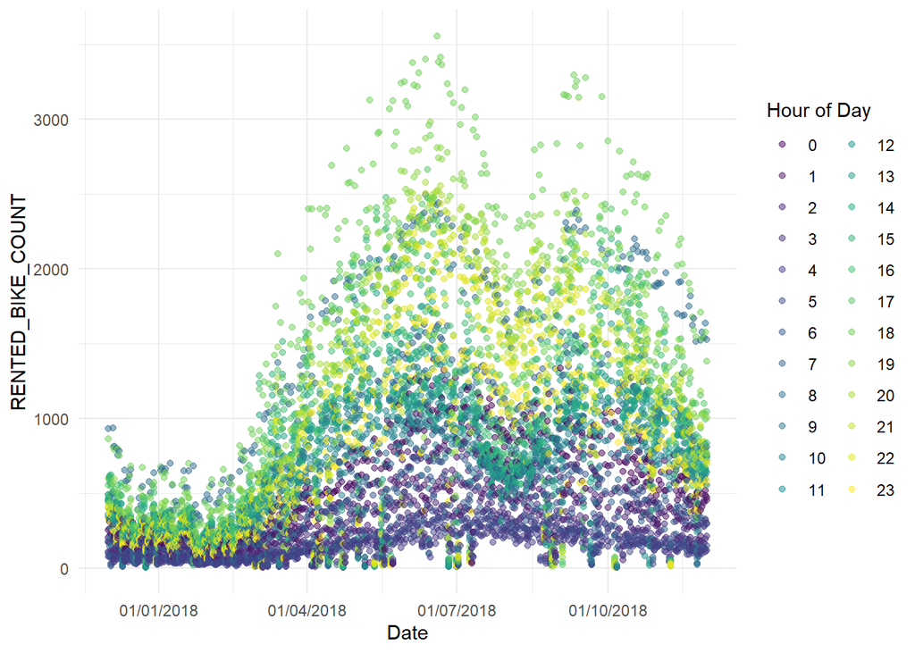

```r
seoul_bike_sharing %>%
  mutate(DATE = as.Date(DATE, format = "%d/%m/%Y")) %>%
  ggplot(aes(x = DATE, y = RENTED_BIKE_COUNT, color = factor(HOUR))) +
  geom_point(alpha = 0.5) +
  scale_x_date(date_labels = "%d/%m/%Y") +
  labs(x = "Date", color = "Hour of Day") +
  theme_minimal()
```

#### Task_22: Create a histogram overlaid with a kernel density curve

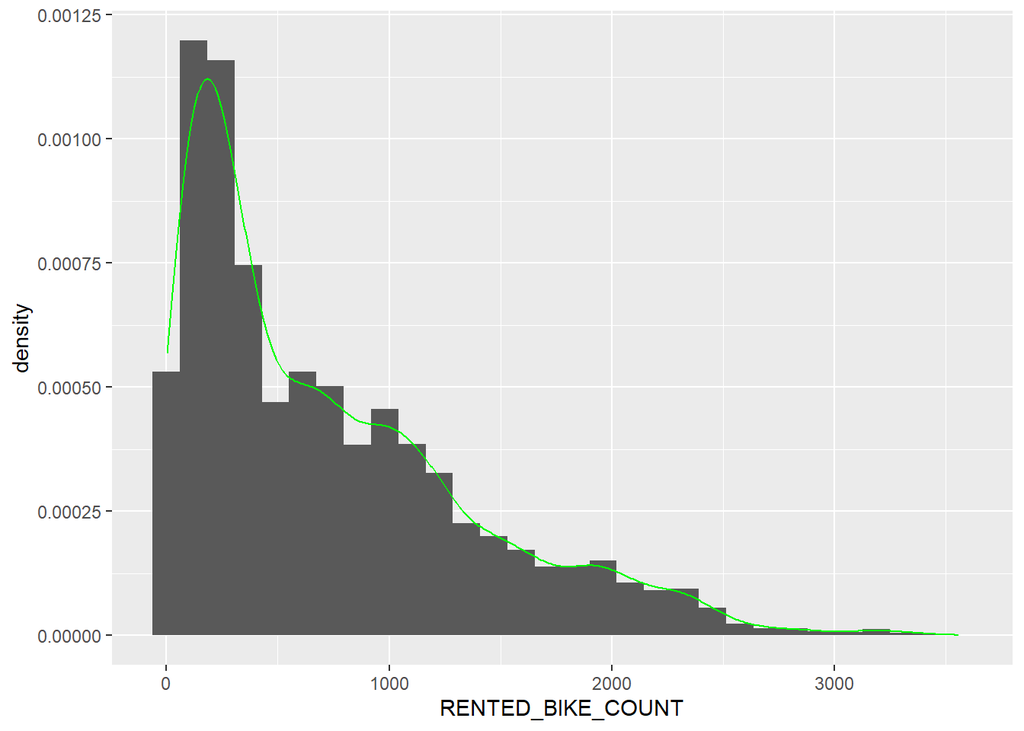

```r
ggplot(seoul_bike_sharing, aes(RENTED_BIKE_COUNT)) +
  geom_histogram(aes(y=..density..))+
  geom_density(col="green")
```

#### Task_23: Use a scatter plot to visualize the correlation between RENTED_BIKE_COUNT and TEMPERATURE by SEASONS

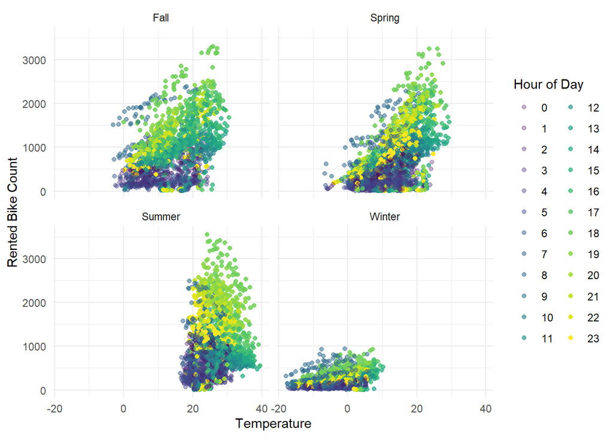

```r
get_season <- function(date) {
  month <- as.POSIXlt(date)$mon + 1  # Extract the month from the date
  case_when(
    month %in% c(3, 4, 5) ~ "Spring",
    month %in% c(6, 7, 8) ~ "Summer",
    month %in% c(9, 10, 11) ~ "Fall",
    TRUE ~ "Winter"
  )
}

# Create a new column "SEASON" based on the date
seoul_bike_sharing <- seoul_bike_sharing %>%
  mutate(SEASON = get_season(DATE))

# Create the scatter plot with facet_wrap
ggplot(seoul_bike_sharing, aes(x = TEMPERATURE, y = RENTED_BIKE_COUNT, color = as.factor(HOUR), alpha = as.factor(HOUR))) +
  geom_point() +
  facet_wrap(~SEASON, nrow = 2) +
  labs(x = "Temperature", y = "Rented Bike Count", color = "Hour of Day", alpha = "Hour of Day") +
  scale_alpha_discrete(range = c(0.3, 1)) +  # Adjust opacity range for discrete scale
  theme_minimal()
```

Comparing this plot to the same plot below, but without grouping by SEASONS, shows how important seasonality is in explaining bike rental counts.

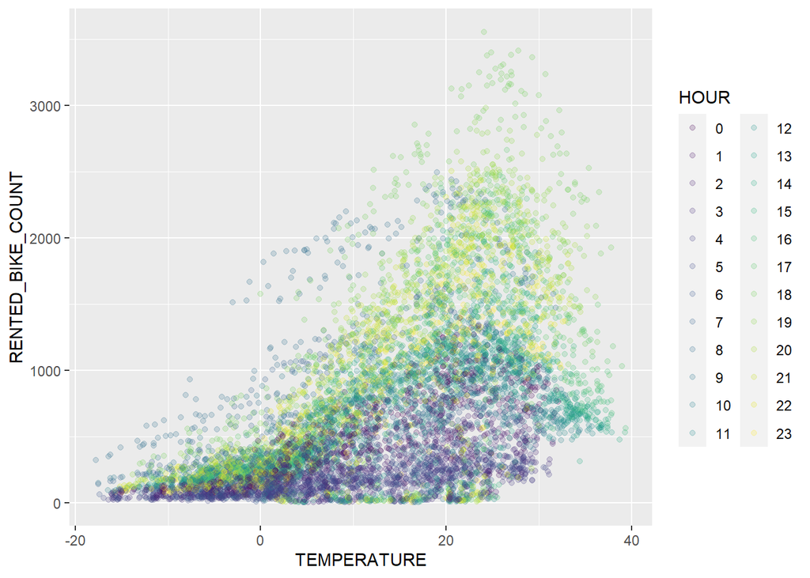

```r
ggplot(seoul_bike_sharing) +
   geom_point(aes(x=TEMPERATURE,y=RENTED_BIKE_COUNT,colour=HOUR),alpha=1/5)
```

#### Task_24: Create a display of four boxplots of RENTED_BIKE_COUNT vs. HOUR grouped by SEASONS

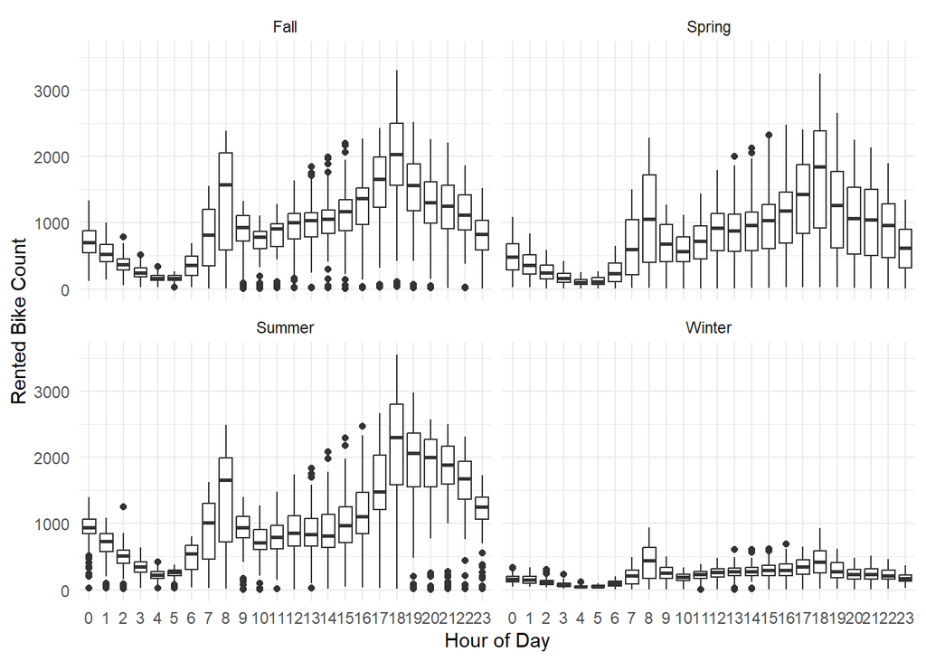

```r
# Create a new column "SEASON" based on the date
seoul_bike_sharing <- seoul_bike_sharing %>%
  mutate(MONTH = as.integer(format(DATE, "%m"))) %>%
  mutate(SEASON = case_when(
    MONTH %in% 3:5 ~ "Spring",
    MONTH %in% 6:8 ~ "Summer",
    MONTH %in% 9:11 ~ "Fall",
    TRUE ~ "Winter"
  )) %>%
  select(-MONTH)  # Remove the temporary MONTH column

# Create boxplots grouped by SEASON and faceted by SEASON
ggplot(seoul_bike_sharing, aes(x = HOUR, y = RENTED_BIKE_COUNT)) +
  geom_boxplot() +
  labs(x = "Hour of Day", y = "Rented Bike Count") +
  facet_wrap(~SEASON, nrow = 2) +
  theme_minimal()
```

#### Task_25: Group the data by DATE, and use the summarize() function to calculate the daily total rainfall and snowfall.

```r
# Group data by DATE and calculate daily total rainfall and snowfall
daily_weather_totals <- seoul_bike_sharing %>%
  group_by(DATE) %>%
  summarize(TotalRainfall = sum(RAINFALL, na.rm = TRUE),
            TotalSnowfall = sum(SNOWFALL, na.rm = TRUE))

# Print the resulting daily weather totals
print(daily_weather_totals)
```

```
## # A tibble: 365 × 3
##    DATE       TotalRainfall TotalSnowfall
##    <date>             <dbl>         <dbl>
##  1 2017-12-01           0             0
##  2 2017-12-02           0             0
##  3 2017-12-03           4             0
##  4 2017-12-04           0.1           0
##  5 2017-12-05           0             0
##  6 2017-12-06           1.3           8.6
##  7 2017-12-07           0            10.4
##  8 2017-12-08           0             0
##  9 2017-12-09           0             0
## 10 2017-12-10           4.1          32.5
## # ℹ 355 more rows
```

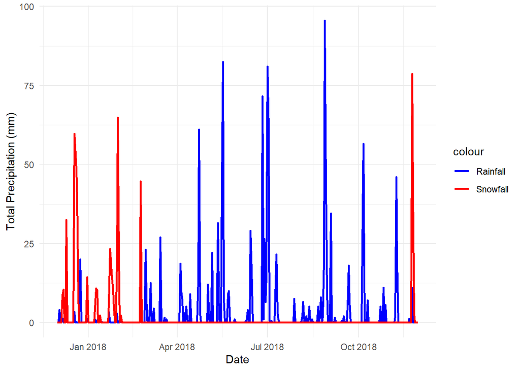

```r
# Create a plot of daily total rainfall and snowfall
ggplot(daily_weather_totals, aes(x = DATE)) +
  geom_line(aes(y = TotalRainfall, color = "Rainfall"), size = 1) +
  geom_line(aes(y = TotalSnowfall, color = "Snowfall"), size = 1) +
  labs(x = "Date", y = "Total Precipitation (mm)") +
  scale_color_manual(values = c("Rainfall" = "blue", "Snowfall" = "red")) +
  theme_minimal()
```

#### Task_26: Determine how many days had snowfall

```r
# Count the number of days with snowfall
days_with_snowfall <- sum(seoul_bike_sharing$SNOWFALL > 0)

# Print the result
print(paste("Number of days with snowfall:", days_with_snowfall))
```

[output not shown]

### Predict Hourly Rented Bike Count using Basic Linear Regression Models

install.packages(“rlang”)

install.packages(“stringr”)

install.packages(“broom”)

```r
library(rlang)
library(stringr)

library(broom)
```

The seoul_bike_sharing_converted_normalized.csv will be our main dataset

```r
bike_sharing_df <- read.csv("E:/Coursera/Data Science with R_Capstone Project/seoul_bike_sharing_converted_normalized.csv")
```

```r
bike_sharing_df <- bike_sharing_df %>%
  select(-DATE, -FUNCTIONING_DAY, -X.2, -X.1, -X, -HOUR, -SEASONS, -HOLIDAY)
```

```r
colnames(bike_sharing_df)[c(34,35)] <- c("HOLIDAY", "NO_HOLIDAY")
```

#### Task_27: Split training and testing data

```r
set.seed(1234)
data_split <- initial_split(bike_sharing_df, prop = 3/4) #set the training dataset with 75% of the original dataset
bike_train <- training(data_split)
bike_test <- testing(data_split)
```

#### Task_28: Build a linear regression model using weather variables only

```r
lm_model_weather <- lm(RENTED_BIKE_COUNT ~ TEMPERATURE + HUMIDITY + WIND_SPEED + VISIBILITY + DEW_POINT_TEMPERATURE + SOLAR_RADIATION + RAINFALL + SNOWFALL,
                        data=bike_train)
summary(lm_model_weather)
```

```
##
## Call:
## lm(formula = RENTED_BIKE_COUNT ~ TEMPERATURE + HUMIDITY + WIND_SPEED +
##     VISIBILITY + DEW_POINT_TEMPERATURE + SOLAR_RADIATION + RAINFALL +
##     SNOWFALL, data = bike_train)
##
## Residuals:
##      Min       1Q   Median       3Q      Max
## -1337.71  -297.09   -59.12   211.28  2334.57
##
## Coefficients:
##                       Estimate Std. Error t value Pr(>|t|)
## (Intercept)             180.67      59.16   3.054  0.00227 **
## TEMPERATURE            2328.91     268.89   8.661  < 2e-16 ***
## HUMIDITY               -967.29     130.37  -7.419 1.33e-13 ***
## WIND_SPEED              391.29      47.76   8.193 3.05e-16 ***
## VISIBILITY               19.69      24.82   0.793  0.42768
## DEW_POINT_TEMPERATURE  -250.91     286.97  -0.874  0.38196
## SOLAR_RADIATION        -444.43      34.54 -12.867  < 2e-16 ***
## RAINFALL              -1824.26     193.90  -9.408  < 2e-16 ***
## SNOWFALL                321.63     124.08   2.592  0.00956 **
## ---
## Signif. codes:  0 '***' 0.001 '**' 0.01 '*' 0.05 '.' 0.1 ' ' 1
##
## Residual standard error: 485.2 on 6342 degrees of freedom
##   (219 observations deleted due to missingness)
## Multiple R-squared:  0.4319, Adjusted R-squared:  0.4312
## F-statistic: 602.7 on 8 and 6342 DF,  p-value: < 2.2e-16
```

#### Task_29:TASK: Build a linear regression model using all variables

```r
lm_model_all <- lm(RENTED_BIKE_COUNT ~ .,
                        data=bike_train)
summary(lm_model_all)
```

```
##
## Call:
## lm(formula = RENTED_BIKE_COUNT ~ ., data = bike_train)
##
## Residuals:
##      Min       1Q   Median       3Q      Max
## -1345.07  -219.83   -11.43   200.62  1810.03
##
## Coefficients: (3 not defined because of singularities)
##                         Estimate Std. Error t value Pr(>|t|)
## (Intercept)             336.1282    52.6423   6.385 1.83e-10 ***
## TEMPERATURE             675.8427   217.1794   3.112 0.001867 **
## HUMIDITY               -962.5891   102.1449  -9.424  < 2e-16 ***
## WIND_SPEED               -0.1969    39.9048  -0.005 0.996063
## VISIBILITY               35.2766    20.0750   1.757 0.078925 .
## DEW_POINT_TEMPERATURE   764.1568   227.3129   3.362 0.000779 ***
## SOLAR_RADIATION         267.0582    41.3751   6.455 1.17e-10 ***
## RAINFALL              -2093.4367   152.0538 -13.768  < 2e-16 ***
## SNOWFALL                269.9654    97.2871   2.775 0.005538 **
## HOUR_0                 -132.2530    32.5927  -4.058 5.01e-05 ***
## HOUR_1                 -230.6053    32.5206  -7.091 1.48e-12 ***
## HOUR_2                 -357.3816    32.7219 -10.922  < 2e-16 ***
## HOUR_3                 -436.8099    32.7899 -13.321  < 2e-16 ***
## HOUR_4                 -498.0917    32.7066 -15.229  < 2e-16 ***
## HOUR_5                 -469.3047    32.8406 -14.290  < 2e-16 ***
## HOUR_6                 -320.1232    32.8418  -9.747  < 2e-16 ***
## HOUR_7                   -7.5412    33.2445  -0.227 0.820554
## HOUR_8                  350.0599    33.1858  10.549  < 2e-16 ***
## HOUR_9                 -100.8611    33.4686  -3.014 0.002592 **
## HOUR_10                -344.0115    34.9835  -9.834  < 2e-16 ***
## HOUR_11                -348.8339    36.7342  -9.496  < 2e-16 ***
## HOUR_12                -312.4168    36.9706  -8.450  < 2e-16 ***
## HOUR_13                -304.0978    38.7014  -7.858 4.57e-15 ***
## HOUR_14                -299.7209    36.9777  -8.105 6.26e-16 ***
## HOUR_15                -216.5520    36.4353  -5.943 2.94e-09 ***
## HOUR_16                 -73.5134    34.9760  -2.102 0.035609 *
## HOUR_17                 213.5063    34.1330   6.255 4.23e-10 ***
## HOUR_18                 682.0979    33.0801  20.620  < 2e-16 ***
## HOUR_19                 402.5790    32.7585  12.289  < 2e-16 ***
## HOUR_20                 327.9847    32.6779  10.037  < 2e-16 ***
## HOUR_21                 322.5391    32.8277   9.825  < 2e-16 ***
## HOUR_22                 202.1670    32.7169   6.179 6.84e-10 ***
## HOUR_23                       NA         NA      NA       NA
## HOLIDAY                -105.8741    22.3364  -4.740 2.18e-06 ***
## NO_HOLIDAY                    NA         NA      NA       NA
## AUTUMN                  342.0001    19.9677  17.128  < 2e-16 ***
## SPRING                  186.2172    19.1625   9.718  < 2e-16 ***
## SUMMER                  167.0077    28.9383   5.771 8.25e-09 ***
## WINTER                        NA         NA      NA       NA
## ---
## Signif. codes:  0 '***' 0.001 '**' 0.01 '*' 0.05 '.' 0.1 ' ' 1
##
## Residual standard error: 375.3 on 6315 degrees of freedom
##   (219 observations deleted due to missingness)
## Multiple R-squared:  0.6616, Adjusted R-squared:  0.6597
## F-statistic: 352.7 on 35 and 6315 DF,  p-value: < 2.2e-16
```

```r
lm_model_all <- lm(RENTED_BIKE_COUNT ~ .,
                        data=bike_train)
summary(lm_model_all$fit)
```

```
##    Min. 1st Qu.  Median    Mean 3rd Qu.    Max.
## -1659.0   337.0   723.4   730.0  1120.4  2243.9
```

#### Task_30: Model evaluation and identification of important variables

```r
# Use model to make prediction
lm_model_weather_pred <- predict(lm_model_weather, newdata = bike_test)
test_results_weather <- data.frame(PREDICTION=lm_model_weather_pred, TRUTH = bike_test$RENTED_BIKE_COUNT)

lm_model_all_pred <- predict(lm_model_all, newdata = bike_test)
test_results_all <- data.frame(PREDICTION = lm_model_all_pred, TRUTH = bike_test$RENTED_BIKE_COUNT)

summary(lm_model_weather)$r.squared #0.4303
```

```
## [1] 0.4318878
```

```r
summary(lm_model_all)$r.squared #0.6589
```

```
## [1] 0.6615725
```

```r
rmse_weather <- sqrt(mean((test_results_weather$TRUTH-test_results_weather$PREDICTION)^2))
rmse_all <- sqrt(mean((test_results_all$TRUTH-test_results_all$PREDICTION)^2))

print(rmse_weather) #474.6247
```

```
## [1] NA
```

```r
print(rmse_all) #361.9543
```

```
## [1] NA
```

```r
# create a data frame of coefficients
coef_df <- tidy(lm_model_all)
```

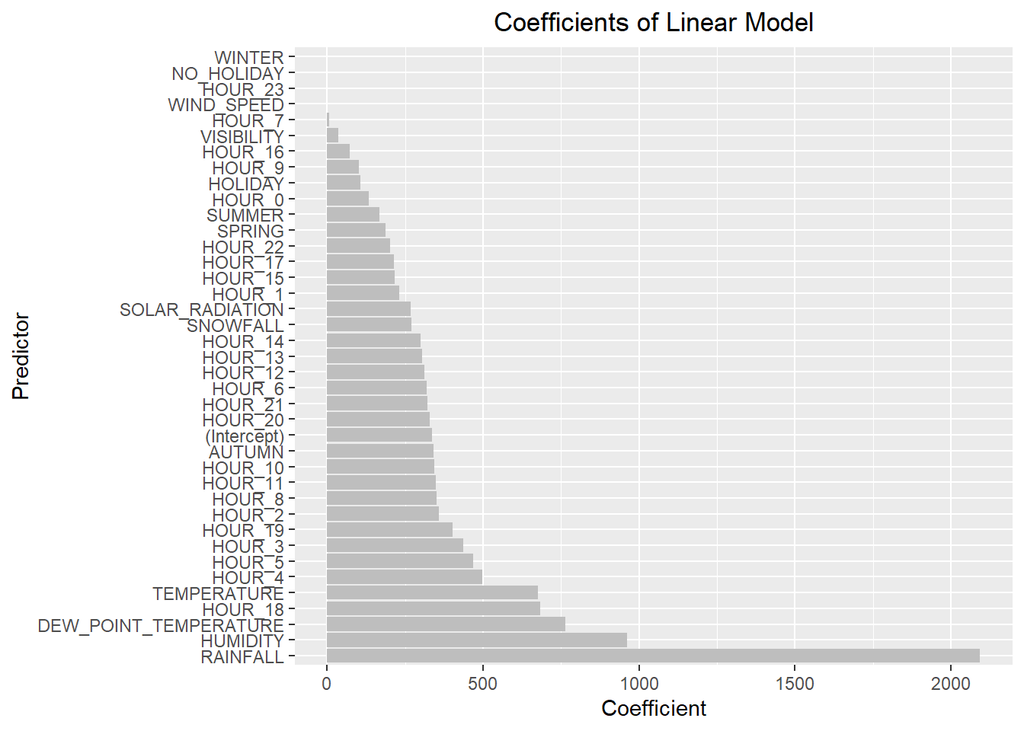

```r
# plot the coefficients in a bar chart (coef plot.png)
ggplot(coef_df, aes(x = reorder(term, desc(abs(estimate))), y = abs(estimate))) +
  geom_bar(stat = "identity", fill = "grey") +
  coord_flip() +
  xlab("Predictor") +
  ylab("Coefficient") +
  ggtitle("Coefficients of Linear Model") +
  theme(plot.title = element_text(hjust = 0.5))
```

### Refine the Baseline Regression Models

```r
#Define a linear regression model specification.
lm_spec <- linear_reg() %>%
  set_engine("lm") %>%
  set_mode("regression")
```

```r
#Split the data into training and testing datasets.
set.seed(1234)
data_split <- initial_split(bike_sharing_df, prop = 4/5)
train_data <- training(data_split)
test_data <- testing(data_split)
```

#### Task_31: Add polynomial terms

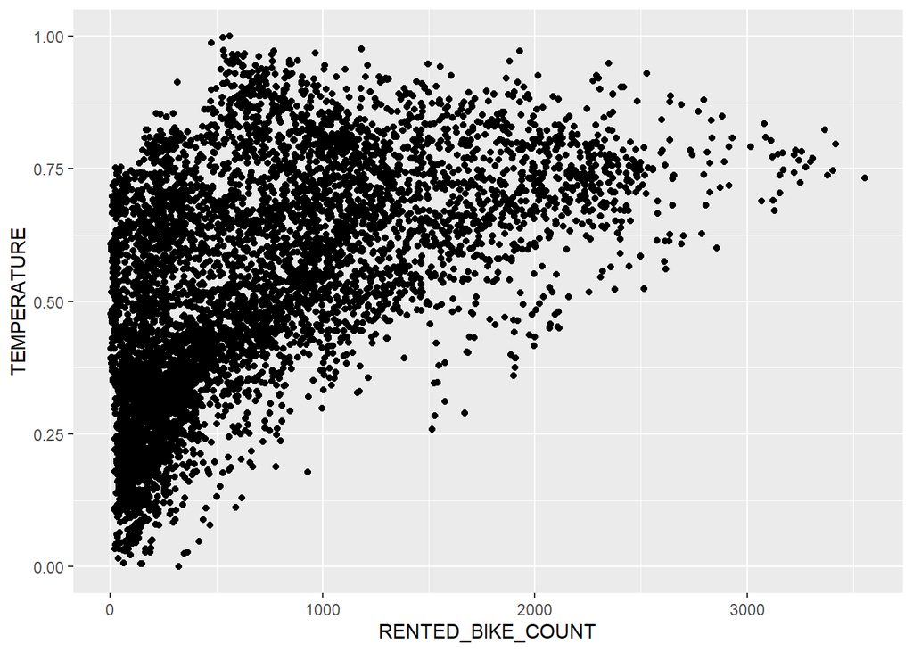

```r
#(poly1.png)
ggplot(data=bike_train, aes(RENTED_BIKE_COUNT, TEMPERATURE)) +
  geom_point() #nonlinearity -> polynomial regression
```

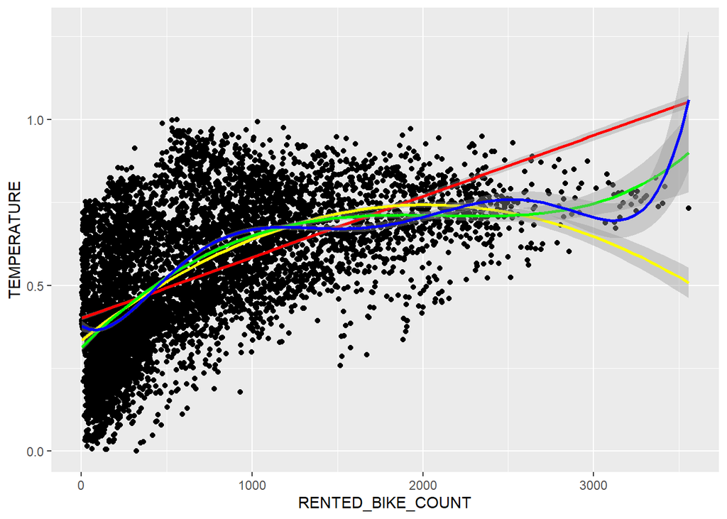

```r
# Plot the higher order polynomial fits
ggplot(data=train_data, aes(RENTED_BIKE_COUNT, TEMPERATURE)) +
    geom_point() +
    geom_smooth(method = "lm", formula = y ~ x, color="red") +
    geom_smooth(method = "lm", formula = y ~ poly(x, 2), color="yellow") +
    geom_smooth(method = "lm", formula = y ~ poly(x, 4), color="green") +
    geom_smooth(method = "lm", formula = y ~ poly(x, 6), color="blue")
```

```r
# Fit a linear model with higher order polynomial on some important variables
lm_poly <- lm(RENTED_BIKE_COUNT ~ poly(TEMPERATURE, 6) +
                poly(HUMIDITY, 4)+
                poly(RAINFALL,2), data = bike_train)
summary(lm_poly$fit)
```

```
##    Min. 1st Qu.  Median    Mean 3rd Qu.    Max.
##  -820.8   356.1   744.4   730.0  1122.8  1475.3
```

```r
lm_poly_pred <- predict(lm_poly, newdata = bike_test) #predict
test_results_poly = data.frame(PREDICTION = lm_poly_pred, TRUTH = bike_test$RENTED_BIKE_COUNT) #create df for test results

#convert all negative prediction to 0 (RENTED_BIKE_COUNT can't be negative)
test_results_poly <- test_results_poly %>%
  mutate(PREDICTION = ifelse(PREDICTION <0, 0, PREDICTION))

#calculate R_squared and RMSE (better than lm_weather but worse than lm_all)
summary(lm_poly)$r.squared #0.4861
```

```
## [1] 0.4826368
```

```r
rmse_poly <- sqrt(mean ( (test_results_poly$TRUTH - test_results_poly$PREDICTION)^2) )
rmse_poly #451.7091
```

```
## [1] NA
```

#### Task_32: Add interaction terms

The effect of predictor variable TEMPERATURE on RENTED_BIKE_COUNT may also depend on other variables such as HUMIDITY, RAINFALL, or both (they interact) and the effect of SEASON on RENTED_BIKE_COUNT may also depend on HOLIDAY, HOUR, or both.

```r
#Task: Add Interaction Terms
lm_poly_interaction <- lm(RENTED_BIKE_COUNT ~ poly(TEMPERATURE, 6) + poly(HUMIDITY, 4)+poly(RAINFALL,2)+
                          RAINFALL*HUMIDITY + TEMPERATURE*HUMIDITY,
                          data = bike_train)
summary(lm_poly_interaction)
```

```
##
## Call:
## lm(formula = RENTED_BIKE_COUNT ~ poly(TEMPERATURE, 6) + poly(HUMIDITY,
##     4) + poly(RAINFALL, 2) + RAINFALL * HUMIDITY + TEMPERATURE *
##     HUMIDITY, data = bike_train)
##
## Residuals:
##      Min       1Q   Median       3Q      Max
## -1323.41  -252.47   -64.05   169.12  2222.50
##
## Coefficients: (3 not defined because of singularities)
##                        Estimate Std. Error t value Pr(>|t|)
## (Intercept)             1607.55      62.86  25.572  < 2e-16 ***
## poly(TEMPERATURE, 6)1  58060.30    1581.04  36.723  < 2e-16 ***
## poly(TEMPERATURE, 6)2  -4804.65     485.56  -9.895  < 2e-16 ***
## poly(TEMPERATURE, 6)3 -12193.35     489.73 -24.898  < 2e-16 ***
## poly(TEMPERATURE, 6)4  -4497.44     463.78  -9.697  < 2e-16 ***
## poly(TEMPERATURE, 6)5  -1387.89     458.64  -3.026  0.00249 **
## poly(TEMPERATURE, 6)6    250.70     461.76   0.543  0.58721
## poly(HUMIDITY, 4)1      8787.66    1556.96   5.644 1.73e-08 ***
## poly(HUMIDITY, 4)2     -7209.18     500.34 -14.409  < 2e-16 ***
## poly(HUMIDITY, 4)3       429.96     486.32   0.884  0.37667
## poly(HUMIDITY, 4)4     -2505.15     478.09  -5.240 1.66e-07 ***
## poly(RAINFALL, 2)1    -57013.33   20738.97  -2.749  0.00599 **
## poly(RAINFALL, 2)2      1165.78     517.39   2.253  0.02428 *
## RAINFALL                     NA         NA      NA       NA
## HUMIDITY                     NA         NA      NA       NA
## TEMPERATURE                  NA         NA      NA       NA
## RAINFALL:HUMIDITY      21033.90    7951.31   2.645  0.00818 **
## HUMIDITY:TEMPERATURE   -2932.53     165.66 -17.702  < 2e-16 ***
## ---
## Signif. codes:  0 '***' 0.001 '**' 0.01 '*' 0.05 '.' 0.1 ' ' 1
##
## Residual standard error: 452 on 6336 degrees of freedom
##   (219 observations deleted due to missingness)
## Multiple R-squared:  0.5073, Adjusted R-squared:  0.5062
## F-statistic:   466 on 14 and 6336 DF,  p-value: < 2.2e-16
```

```r
lm_poly_interaction_pred <- predict(lm_poly_interaction, newdata = bike_test)
test_results_poly_interaction <- data.frame(PREDICTION = lm_poly_interaction_pred, TRUTH=bike_test$RENTED_BIKE_COUNT)

#model performance (improved model)
summary(lm_poly_interaction)$r.squared #0.5086
```

```
## [1] 0.5073318
```

```r
rmse_poly_interaction <- rmse(test_results_poly_interaction, TRUTH, PREDICTION )
rmse_poly_interaction #442
```

```
## # A tibble: 1 × 3
##   .metric .estimator .estimate
##   <chr>   <chr>          <dbl>
## 1 rmse    standard        445.
```

#### Task_33: Add regularization

install.packages(“glmnet”)

install.packages(“yardstick”)

```r
library(glmnet)

library(yardstick)
```

```r
#prediction function
model_prediction <- function(lm_model, test_data) {
  results <- lm_model %>%
    predict(new_data=test_data) %>%
    mutate(TRUTH=test_data$RENTED_BIKE_COUNT)
  results[results<0] <-0
  return(results)
}

#model evaluation function
model_evaluation <- function(results) {
  rmse = rmse(results, truth=TRUTH, estimate=.pred)
  rsq = rsq(results, truth=TRUTH, estimate=.pred)
  print(rmse)
  print(rsq)
}
```

```r
#Use grid to define the best penalty (lambda)
penalty_value <- 10^seq(-4,4, by = 0.5) #penalty values ranging from 10^-4 to 10^4
x = as.matrix(bike_train[,-1]) #define a matrix for CV
y= bike_train$RENTED_BIKE_COUNT
```

```r
#We can use cross-validation to define the lambda with 10-fold validation

# Impute missing values with mean
x[is.na(x)] <- mean(x, na.rm = TRUE)
y[is.na(y)] <- mean(y, na.rm = TRUE)

# Run cross-validation for Ridge, Lasso, and Elastic Net
cv_ridge <- cv.glmnet(x, y, alpha = 0, lambda = penalty_value, nfolds = 10)
cv_lasso <- cv.glmnet(x, y, alpha = 1, lambda = penalty_value, nfolds = 10)
cv_elasticnet <- cv.glmnet(x, y, alpha = 0.5, lambda = penalty_value, nfolds = 10)
```